# Univariate descriptive analysis preprocessed

## cinema

[1] FALSE FALSE FALSE FALSE FALSE FALSE

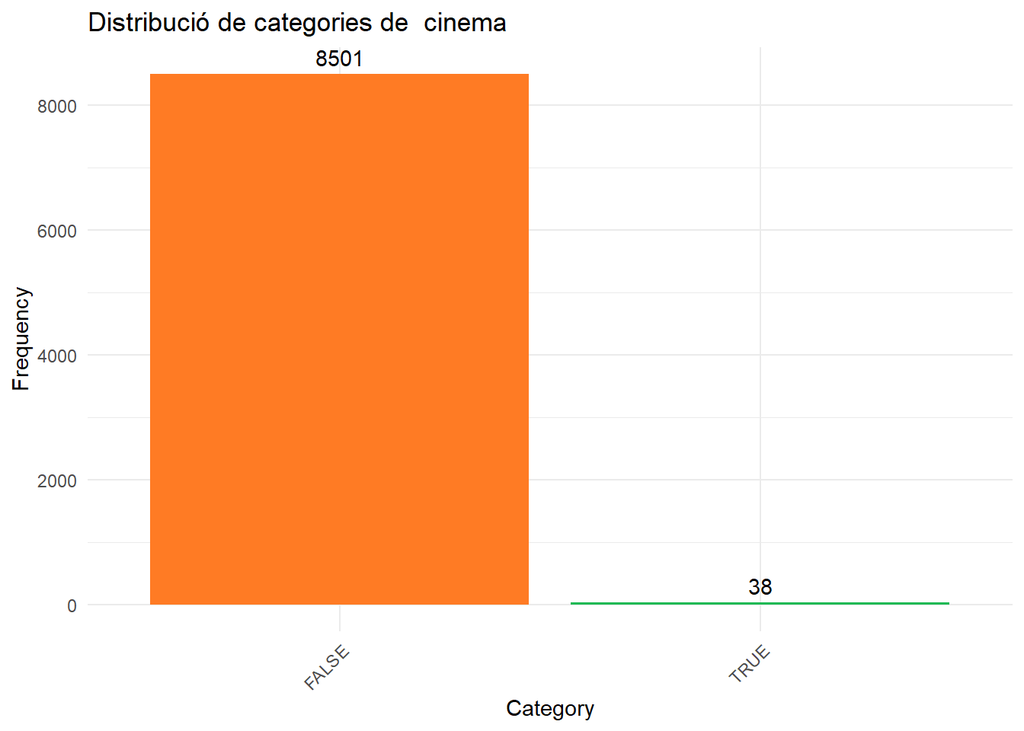

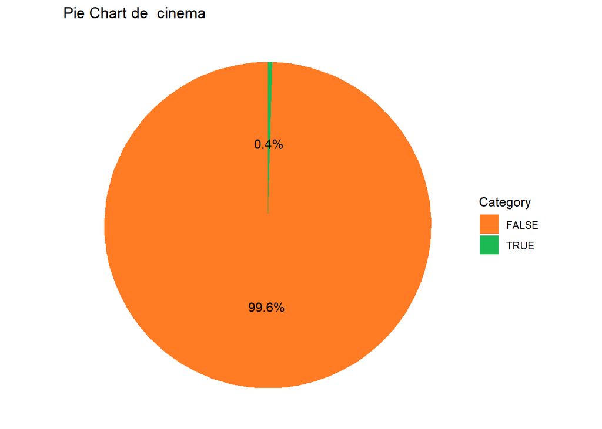

Nombre de modalitats: 2

Moda: FALSE

Freqüència màxima: 8501

## latino

[1] FALSE FALSE FALSE FALSE FALSE FALSE

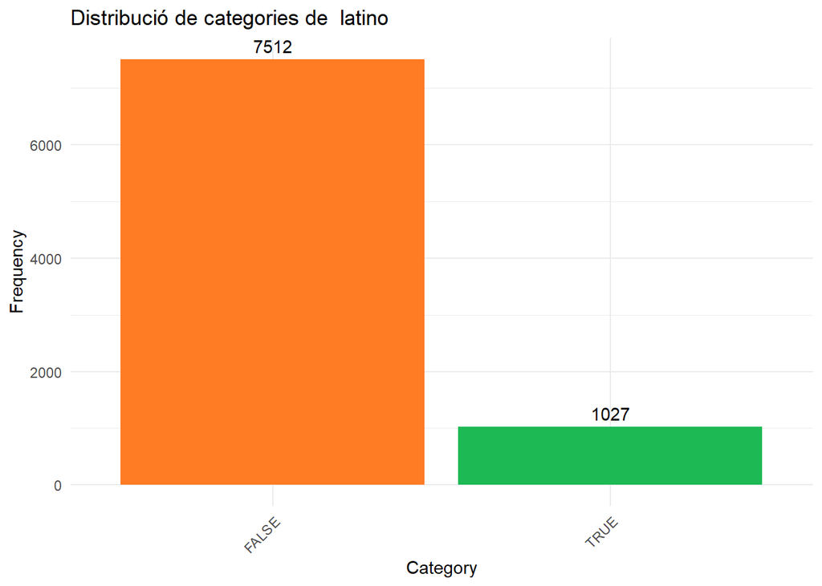

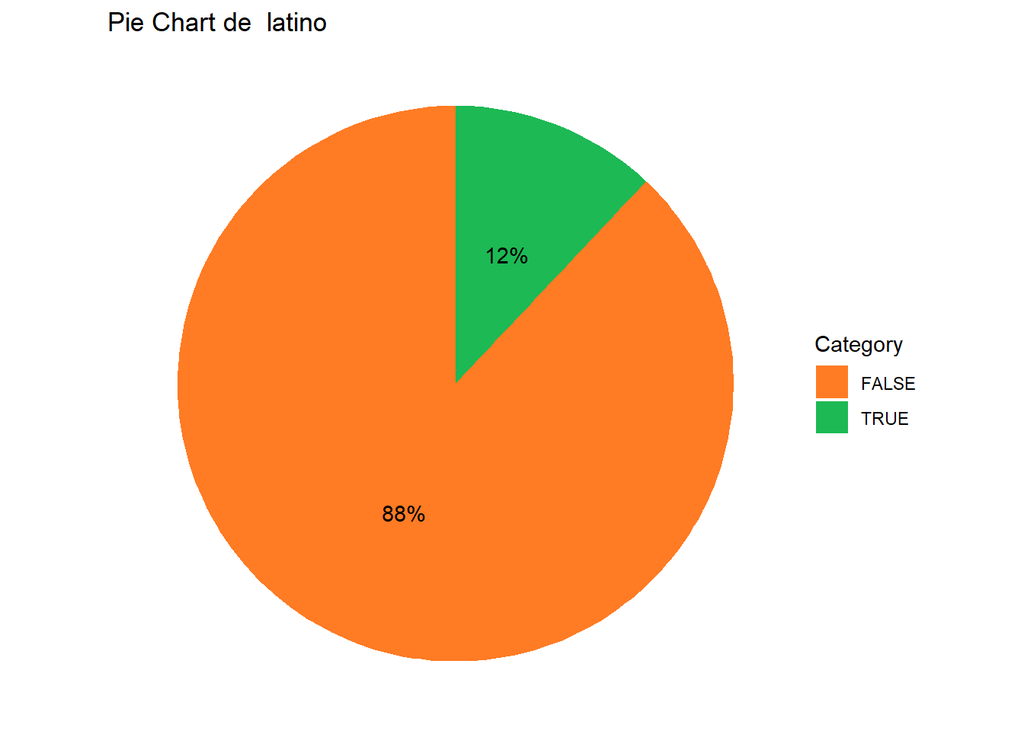

Nombre de modalitats: 2

Moda: FALSE

Freqüència màxima: 7512

## collab

[1] TRUE TRUE TRUE TRUE TRUE TRUE

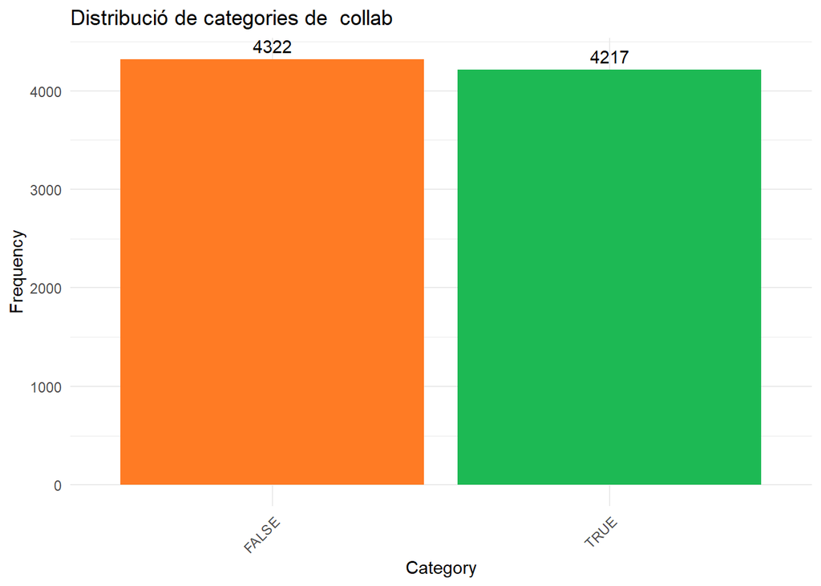

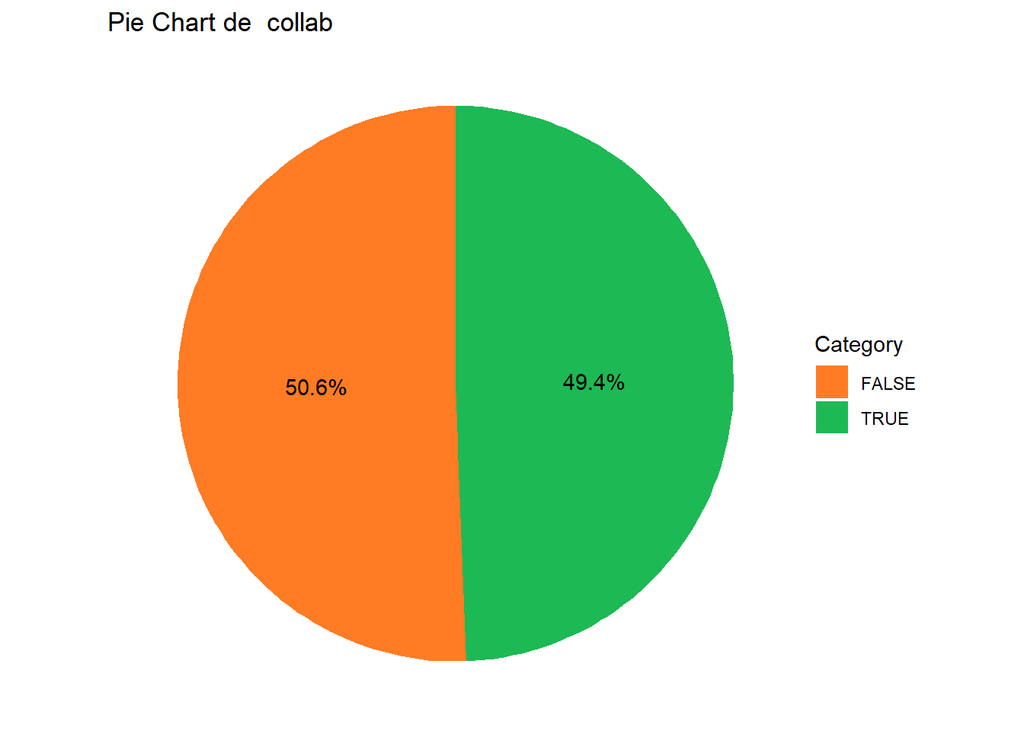

Nombre de modalitats: 2

Moda: FALSE

Freqüència màxima: 4322

## explicit

[1] TRUE FALSE FALSE FALSE FALSE FALSE

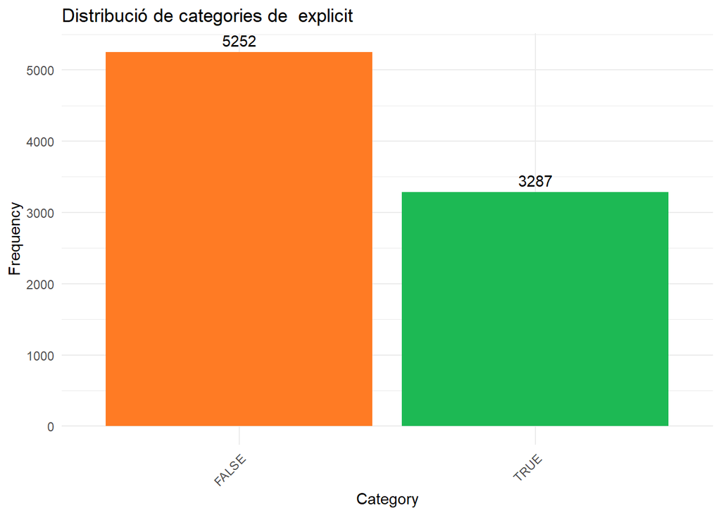

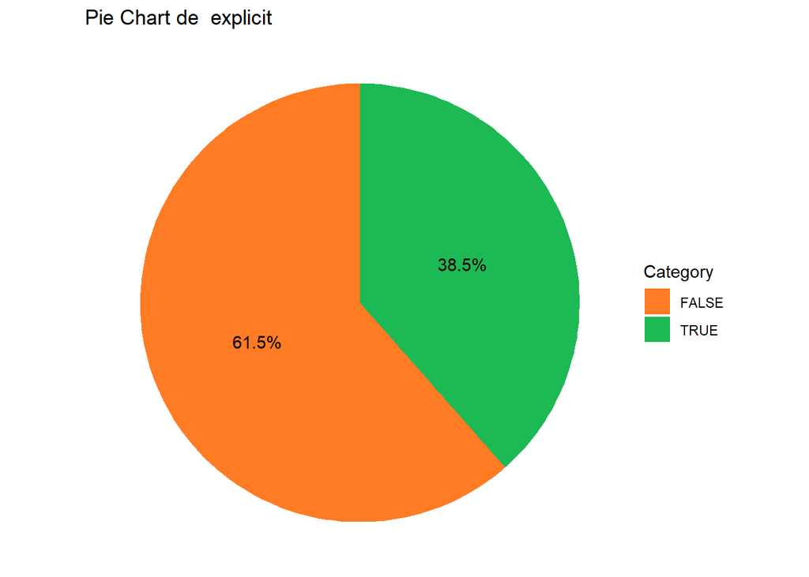

Nombre de modalitats: 2

Moda: FALSE

Freqüència màxima: 5252

## danceability

[1] 0.681 0.748 0.720 0.476 0.735 0.783

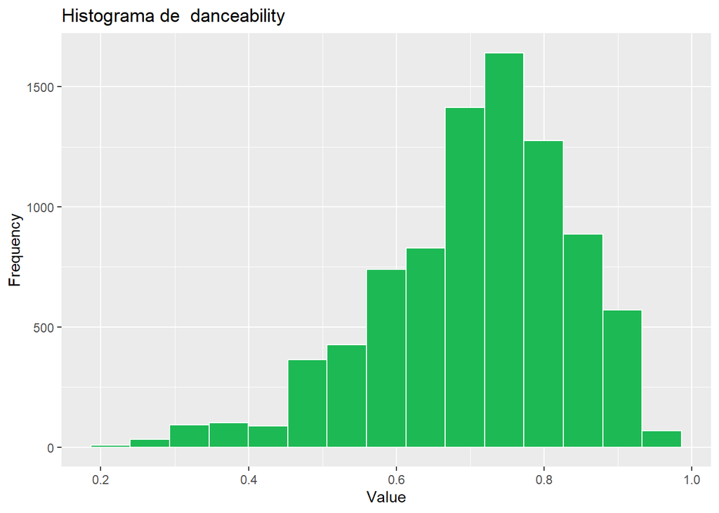

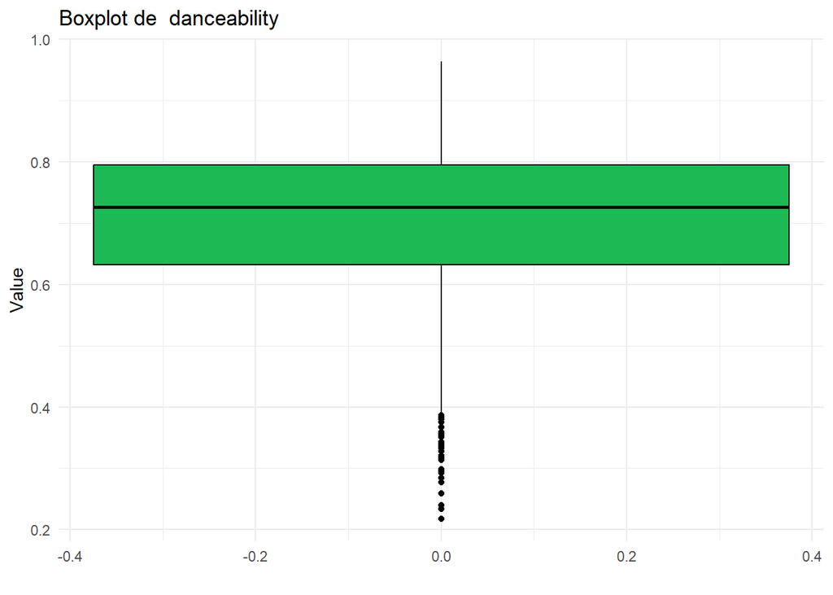

Mínim: 0.218 Màxim: 0.964

Primer quartil: 0.632 Mediana: 0.726 Tercer quartil: 0.795 Mitjana: 0.7072658

Desviació estàndar: 0.129094745561573 Variància: 0.182526482160439

## energy

[1] 0.594 0.524 0.763 0.718 0.451 0.623

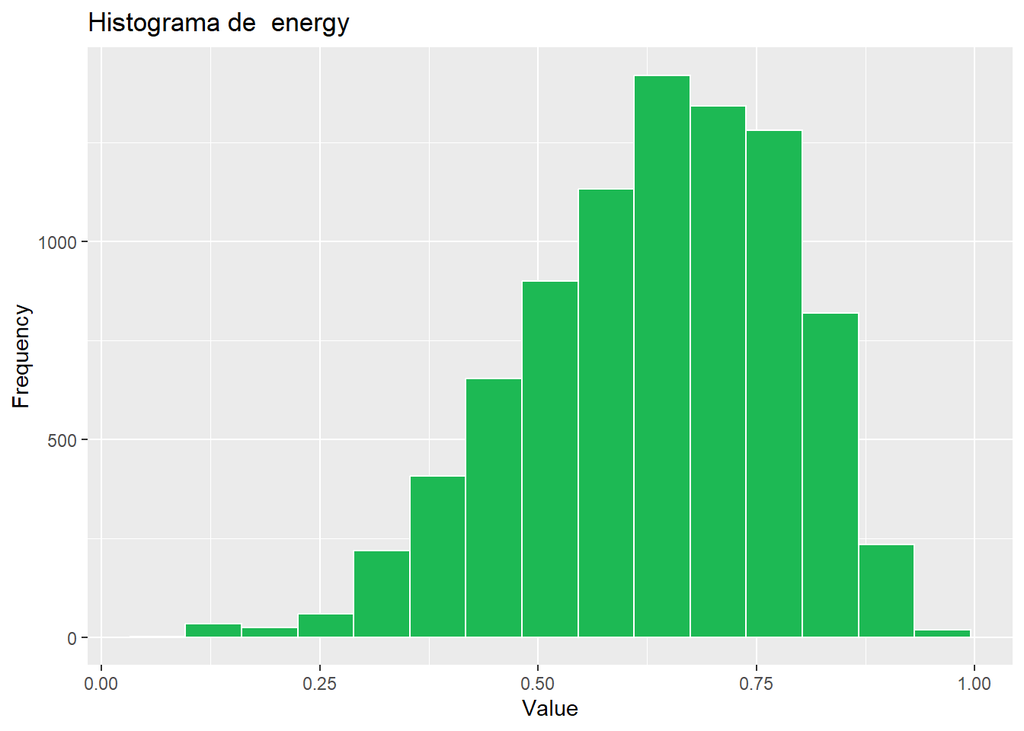

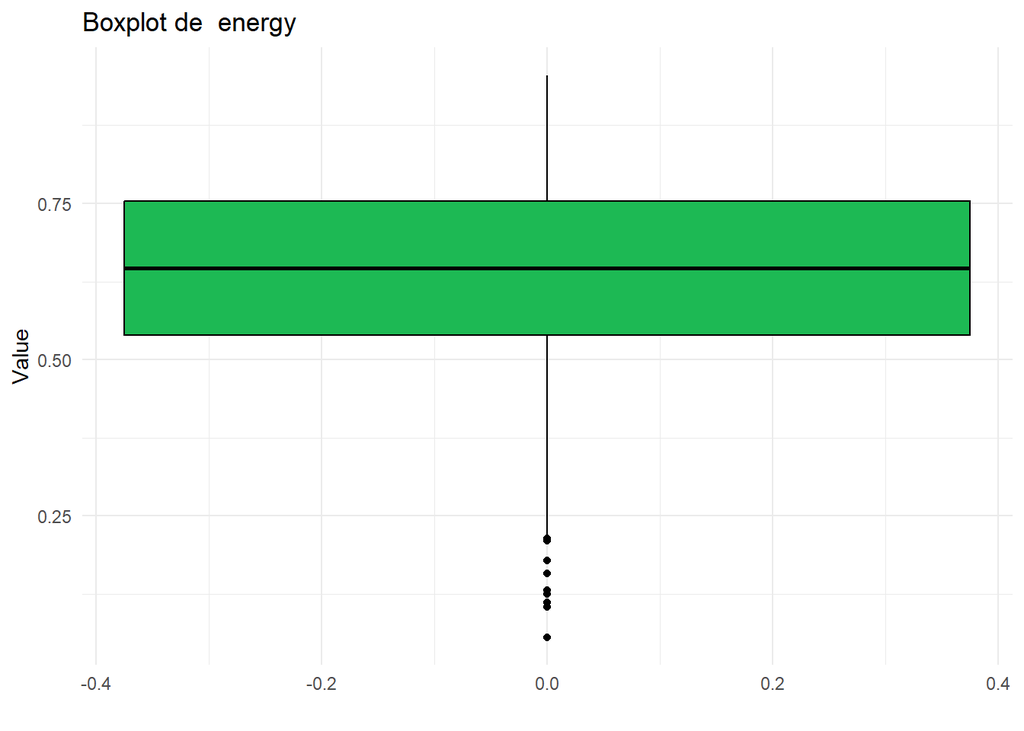

Mínim: 0.0561 Màxim: 0.955

Primer quartil: 0.539 Mediana: 0.646 Tercer quartil: 0.754 Mitjana: 0.6341174

Desviació estàndar: 0.148481740360266 Variància: 0.234154985720578

## key

[1] 7 8 9 8 0 7 Levels: 0 1 2 3 4 5 6 7 8 9 10 11

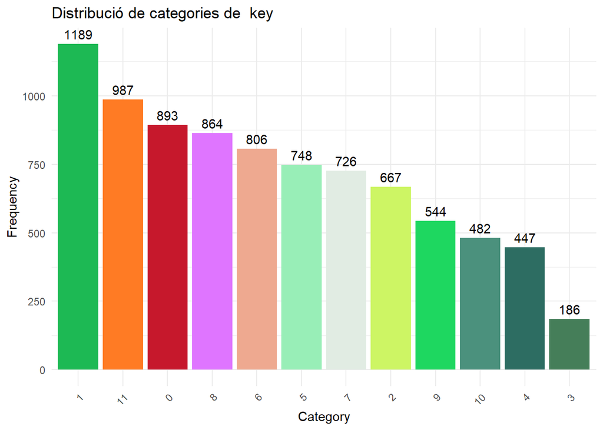

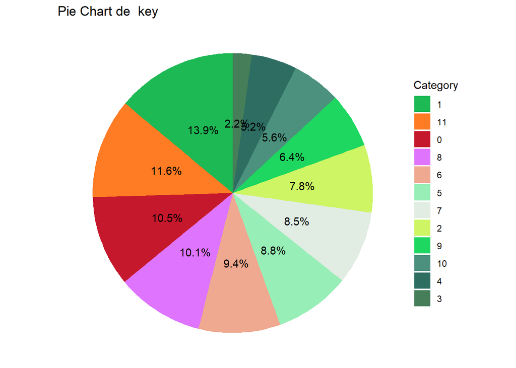

Nombre de modalitats: 12

Moda: 1

Freqüència màxima: 1189

## major_mode

[1] TRUE TRUE FALSE TRUE TRUE TRUE Levels: FALSE TRUE

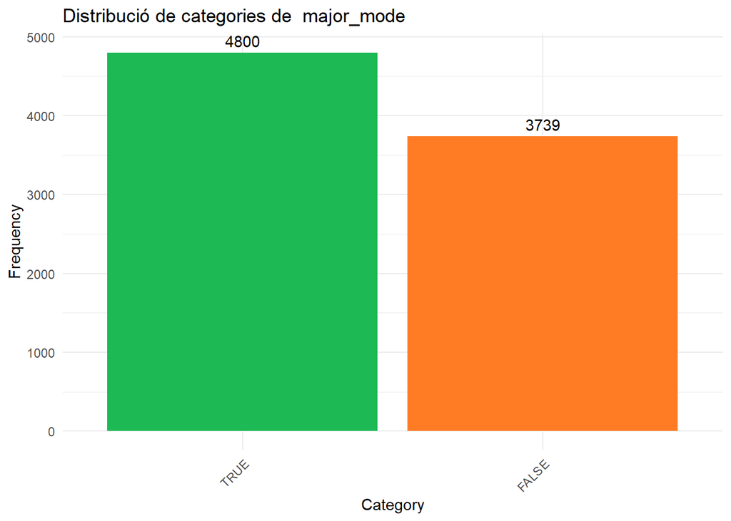

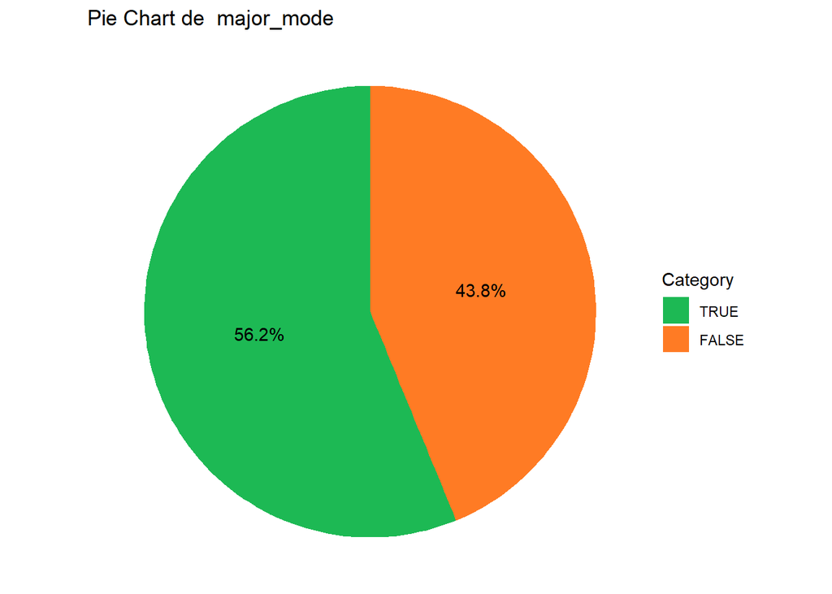

Nombre de modalitats: 2

Moda: TRUE

Freqüència màxima: 4800

## time_signature

[1] 4 4 4 4 4 4 Levels: 1 3 4 5

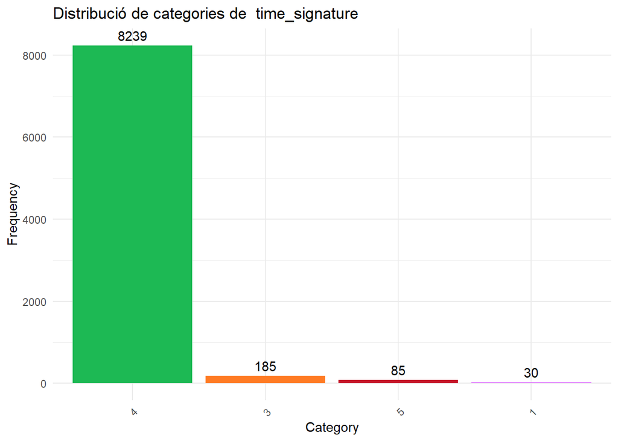

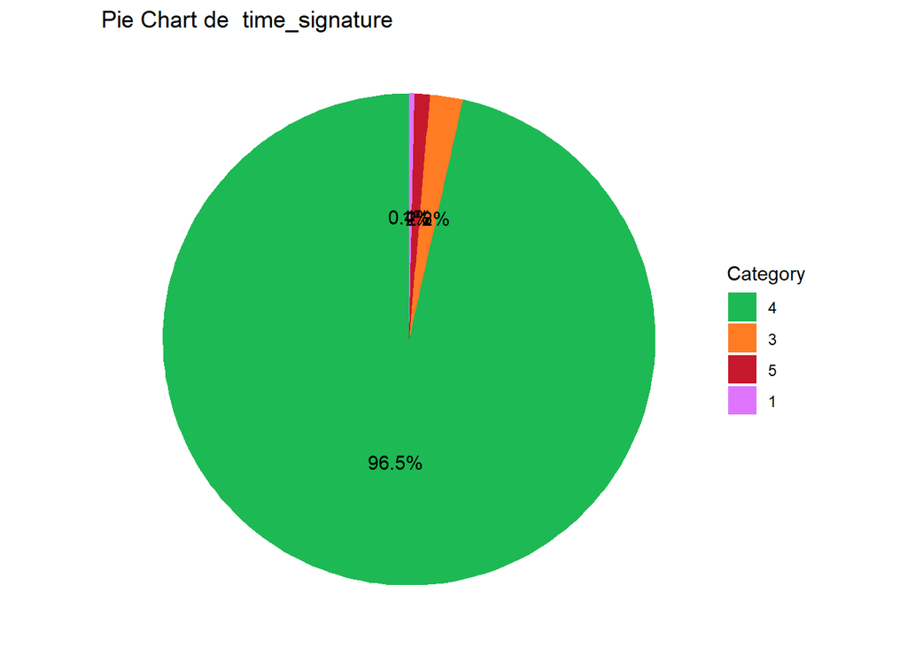

Nombre de modalitats: 4

Moda: 4

Freqüència màxima: 8239

## loudness

[1] -7.028 -5.599 -4.068 -5.309 -8.374 -6.126

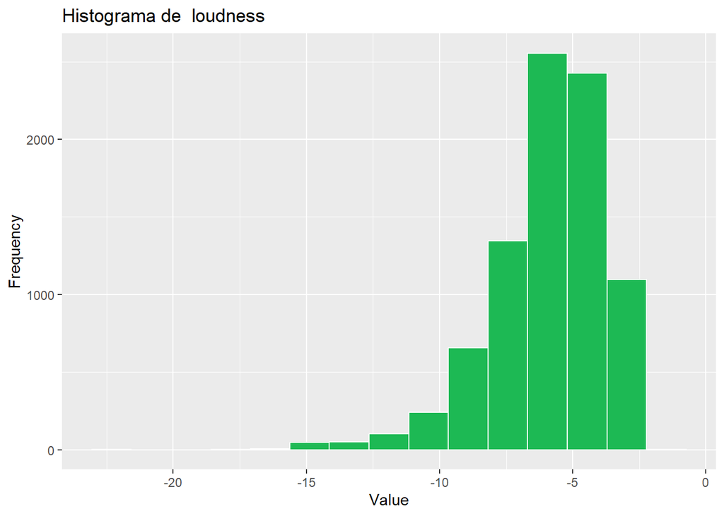

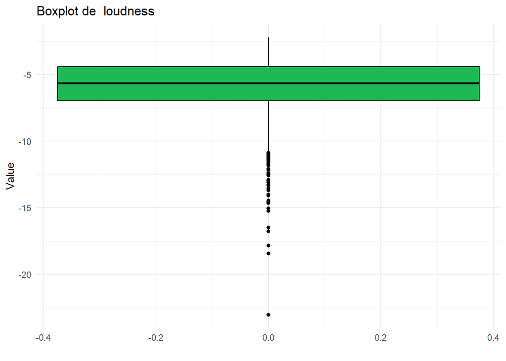

Mínim: -23.023 Màxim: -2.188

Primer quartil: -6.976 Mediana: -5.655 Tercer quartil: -4.41 Mitjana: -5.937009

Desviació estàndar: 2.14073284242375 Variància: -0.360574281035863

## speechiness

[1] 0.2820 0.0338 0.0523 0.0576 0.0585 0.0800

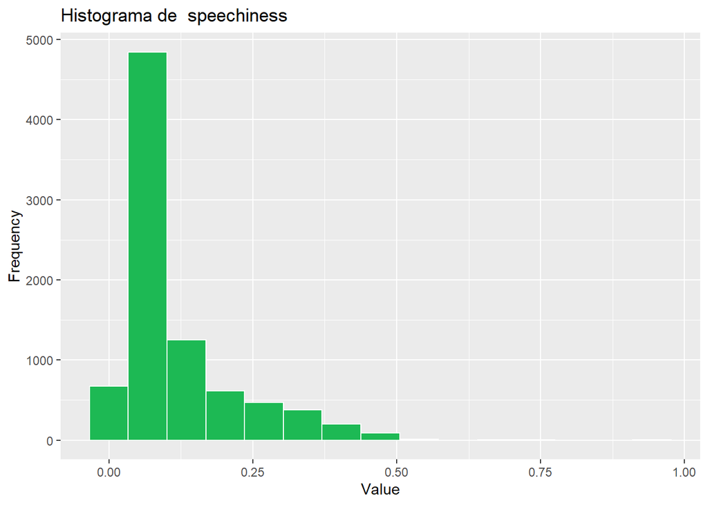

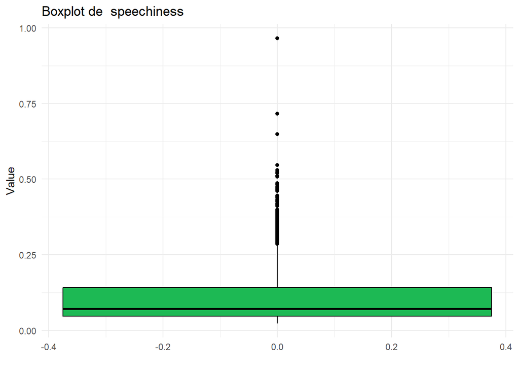

Mínim: 0.0232 Màxim: 0.966

Primer quartil: 0.0472 Mediana: 0.0714 Tercer quartil: 0.142 Mitjana: 0.1150794

Desviació estàndar: 0.101065931613842 Variància: 0.878227825867664

## acousticness

[1] 0.1650 0.4140 0.4060 0.0784 0.0631 0.3380

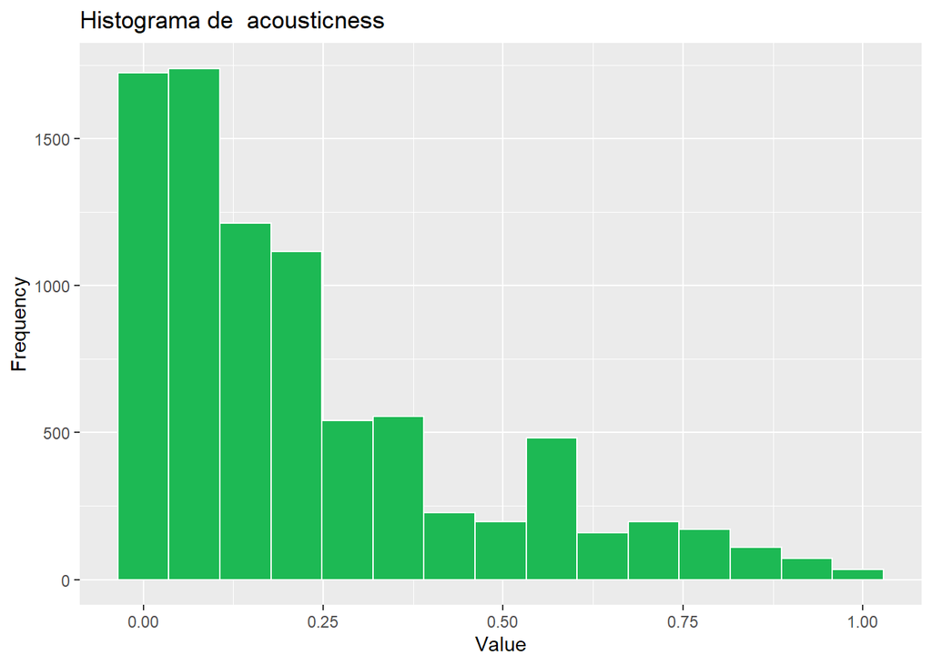

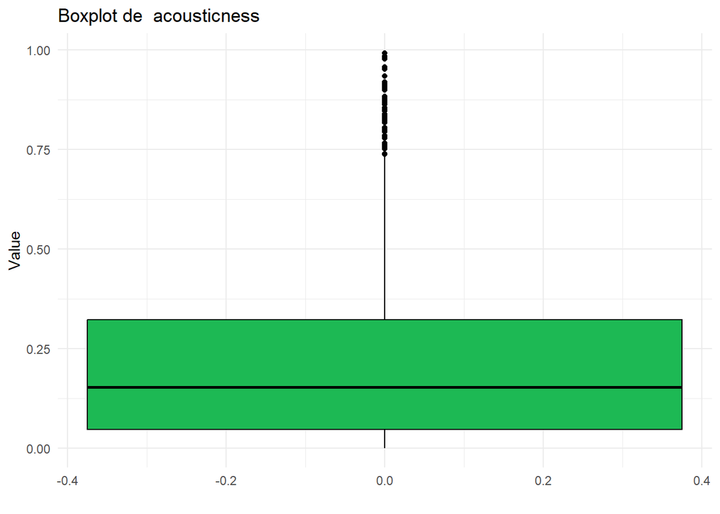

Mínim: 0.000248 Màxim: 0.993

Primer quartil: 0.047 Mediana: 0.153 Tercer quartil: 0.323 Mitjana: 0.2248899

Desviació estàndar: 0.22666531426428 Variància: 1.00789462994329

## liveness

[1] 0.1340 0.1110 0.1800 0.1220 0.3250 0.0975

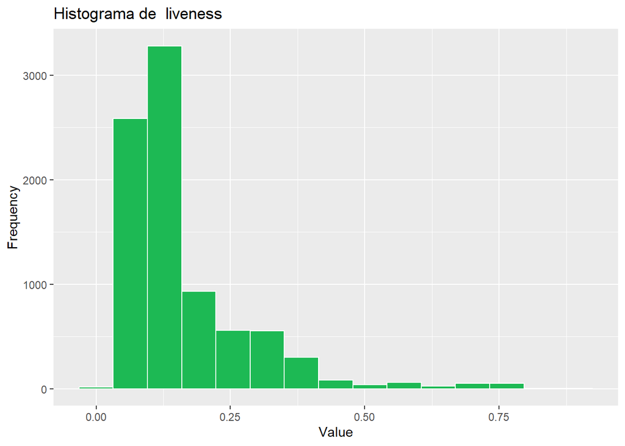

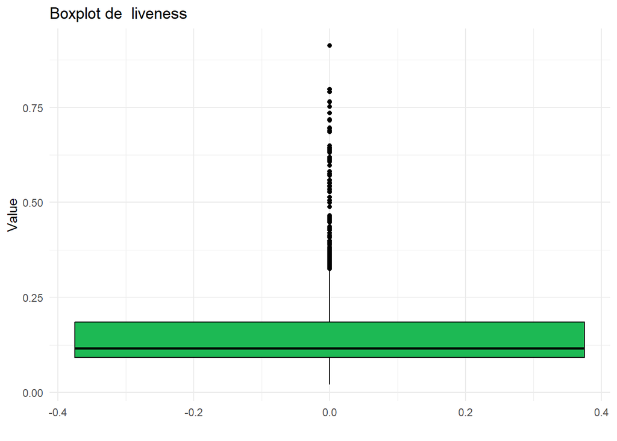

Mínim: 0.0215 Màxim: 0.913

Primer quartil: 0.0919 Mediana: 0.116 Tercer quartil: 0.185 Mitjana: 0.1622061

Desviació estàndar: 0.119265713950301 Variància: 0.735272780308006

## valence

[1] 0.5350 0.6610 0.7420 0.1420 0.0862 0.4470

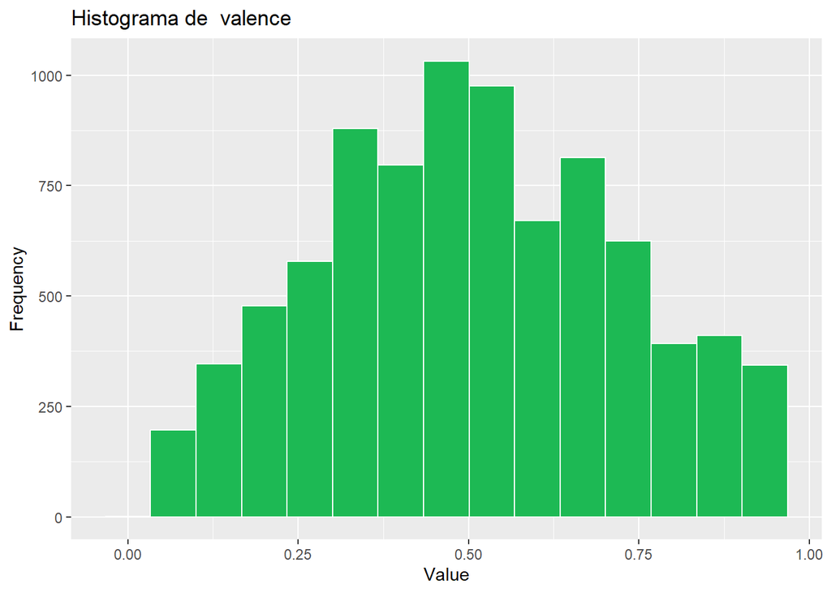

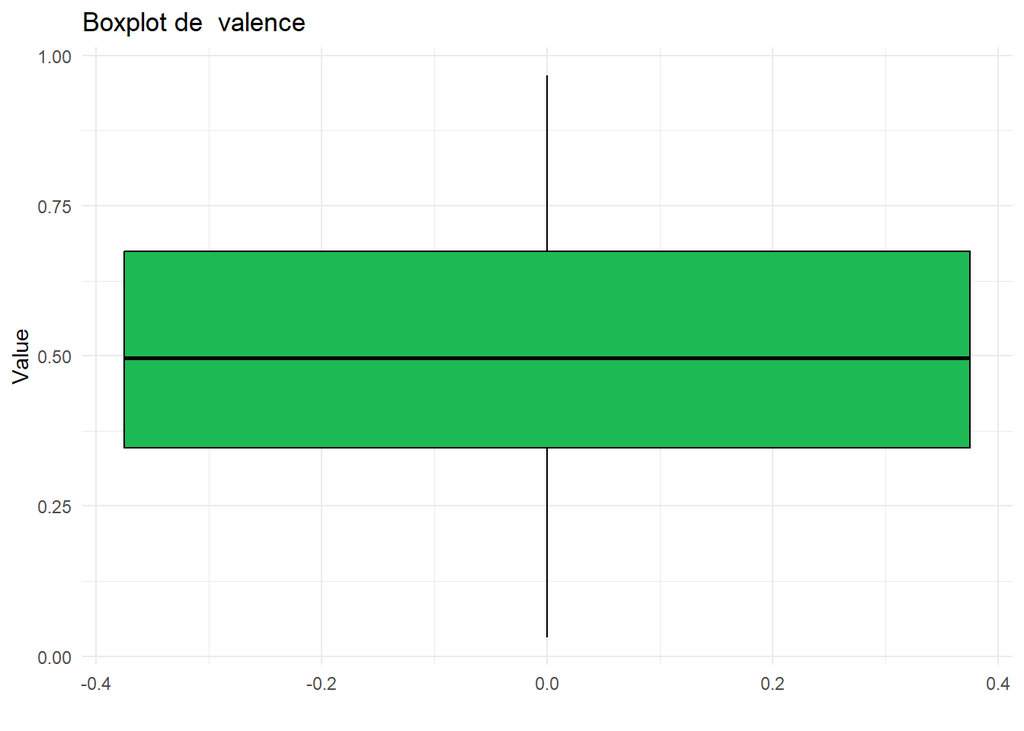

Mínim: 0.032 Màxim: 0.967

Primer quartil: 0.347 Mediana: 0.497 Tercer quartil: 0.674 Mitjana: 0.5066614

Desviació estàndar: 0.218237011257671 Variància: 0.43073543007146

## tempo

[1] 186.054 95.010 101.965 199.864 117.973 100.048

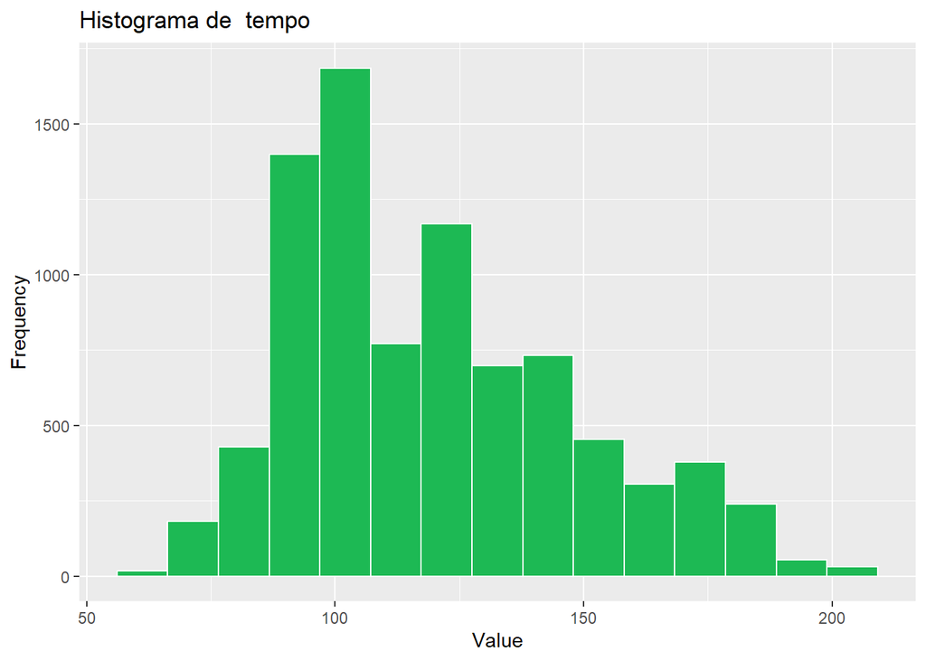

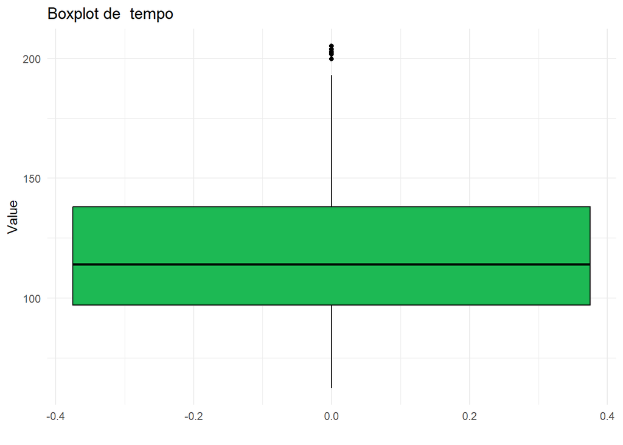

Mínim: 62.446 Màxim: 205.272

Primer quartil: 97.062 Mediana: 114.066 Tercer quartil: 138.041 Mitjana: 119.685

Desviació estàndar: 28.1415000803698 Variància: 0.235129692477456

## duration

[1] 230.453 244.960 251.088 205.946 245.200 214.480

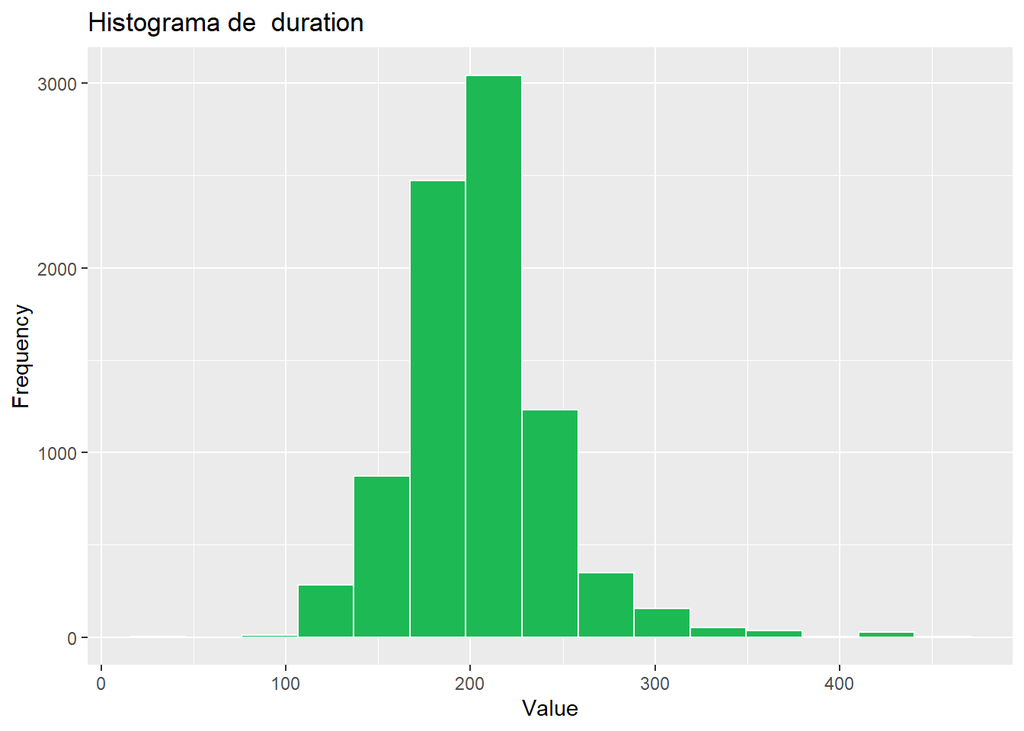

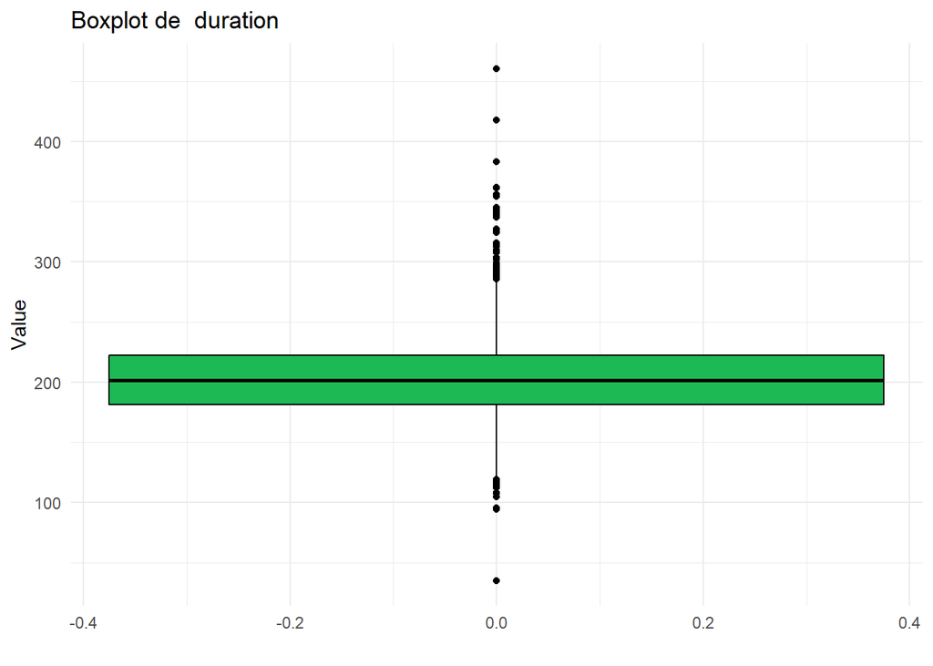

Mínim: 35.24 Màxim: 460.573

Primer quartil: 181.263 Mediana: 201.818 Tercer quartil: 222.294 Mitjana: 204.5155

Desviació estàndar: 38.9530901513347 Variància: 0.190465213095534

## streams

[1] 25734078 23519705 21216399 19852704 18316326 18064374

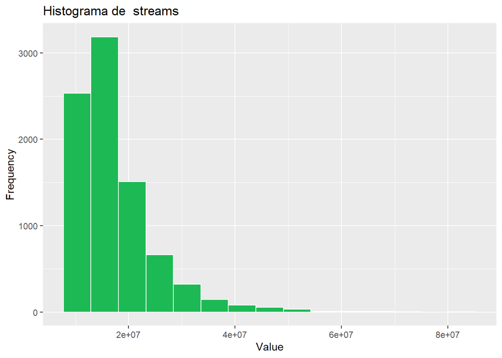

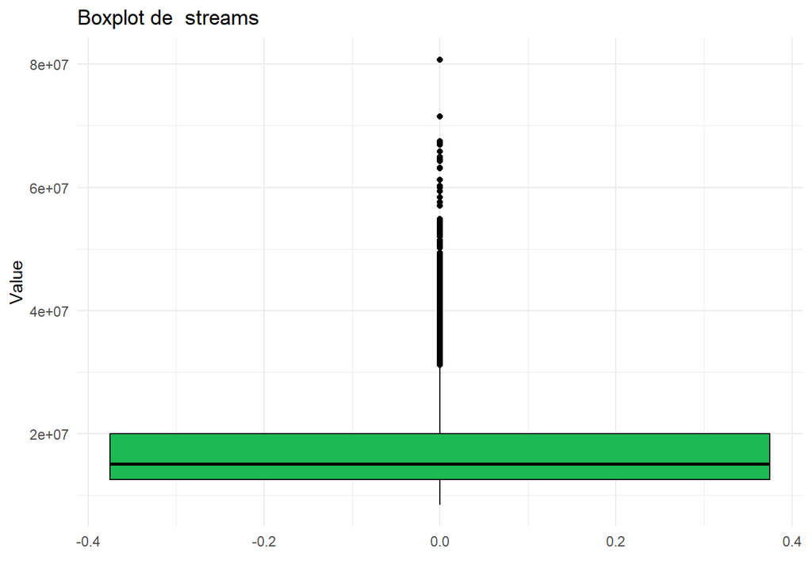

Mínim: 8454914 Màxim: 80764045

Primer quartil: 12533053 Mediana: 15092583 Tercer quartil: 19942896 Mitjana: 17441184

Desviació estàndar: 7296112.17329583 Variància: 0.418326655610649

## year_release

[1] 2016 2016 2016 2016 2016 2016 32 Levels: 1942 1957 1959 1962 1963 1964 1965 1975 1977 1980 1984 1987 … 2021

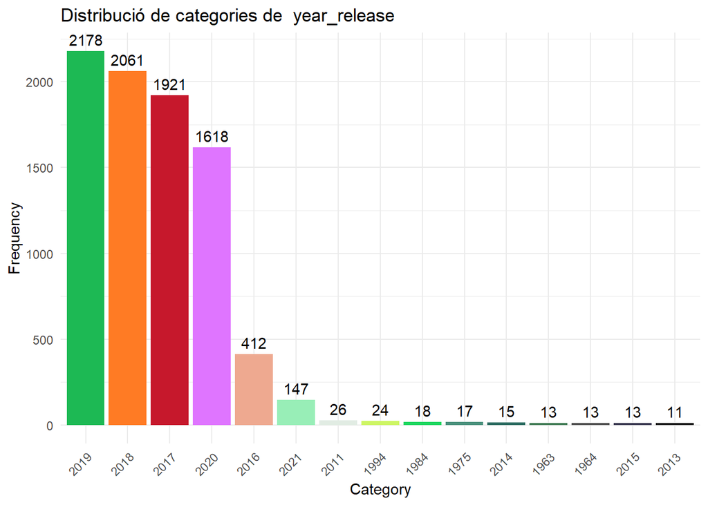

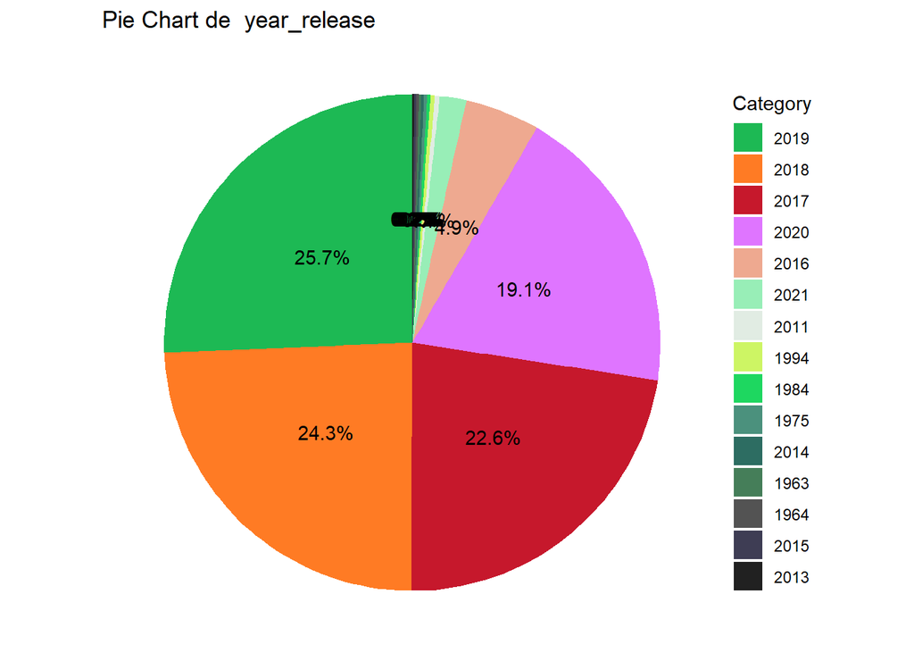

Nombre de modalitats: 32

Moda: 2019

Freqüència màxima: 2178

## month_release

[1] 11 7 10 8 12 10 Levels: 1 2 3 4 5 6 7 8 9 10 11 12

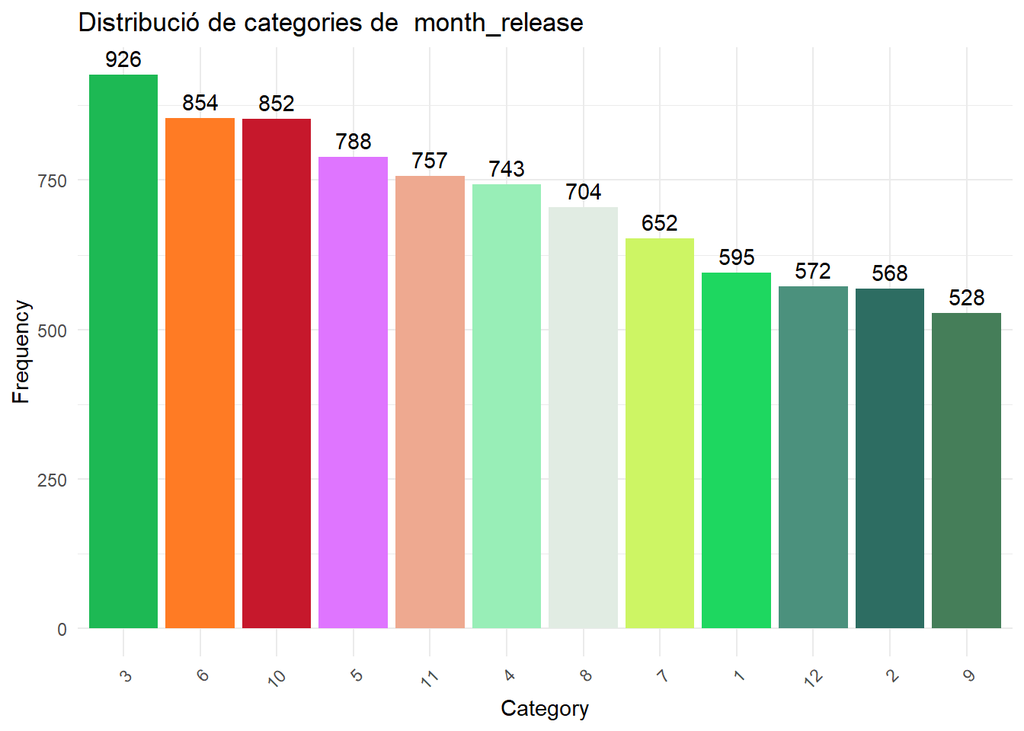

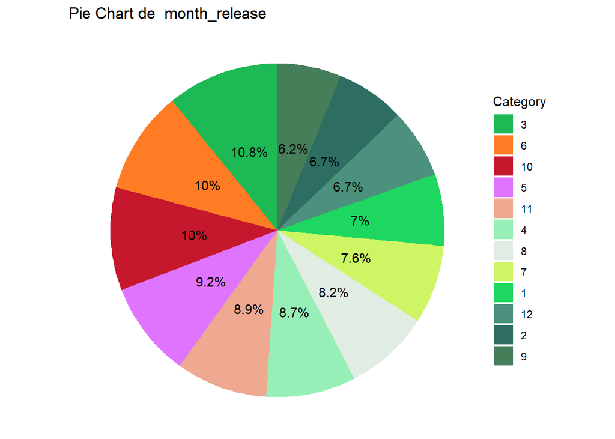

Nombre de modalitats: 12

Moda: 3

Freqüència màxima: 926

## day_release

[1] 25 29 21 5 9 11 31 Levels: 1 2 3 4 5 6 7 8 9 10 11 12 13 14 15 16 17 18 19 20 21 22 23 … 31

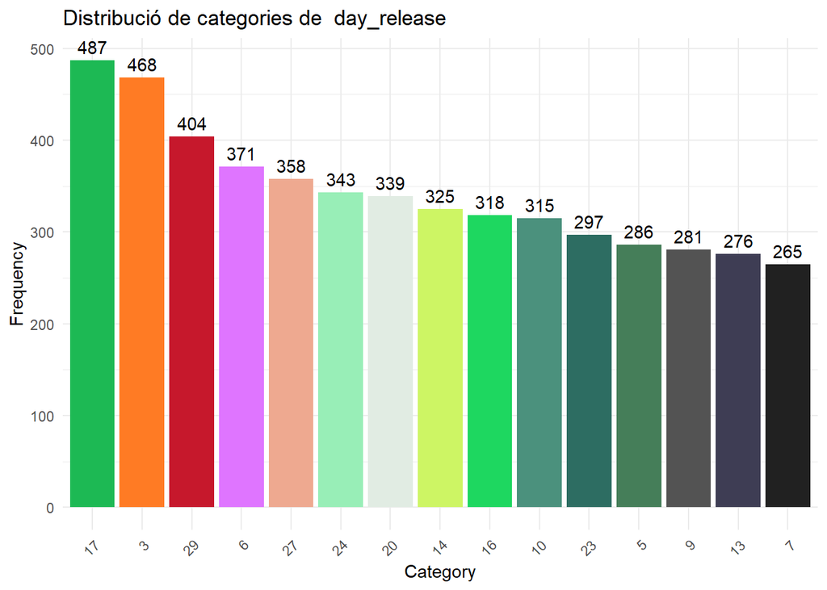

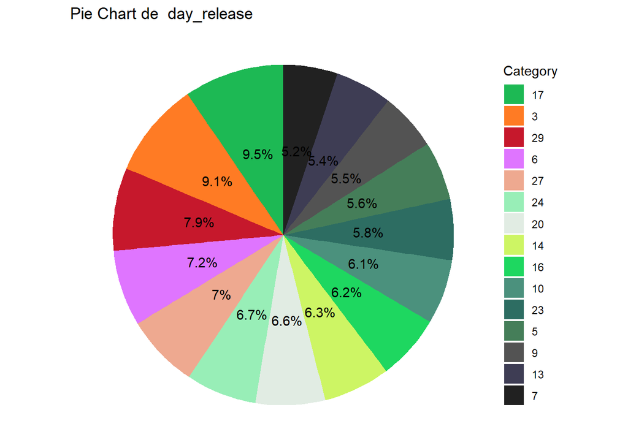

Nombre de modalitats: 31

Moda: 17

Freqüència màxima: 487

## weekday_release

[1] viernes viernes viernes viernes viernes martes Levels: domingo jueves lunes martes miércoles sábado viernes

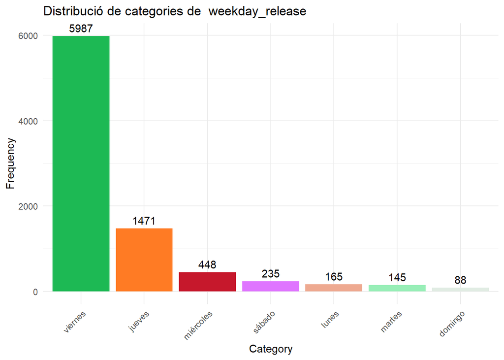

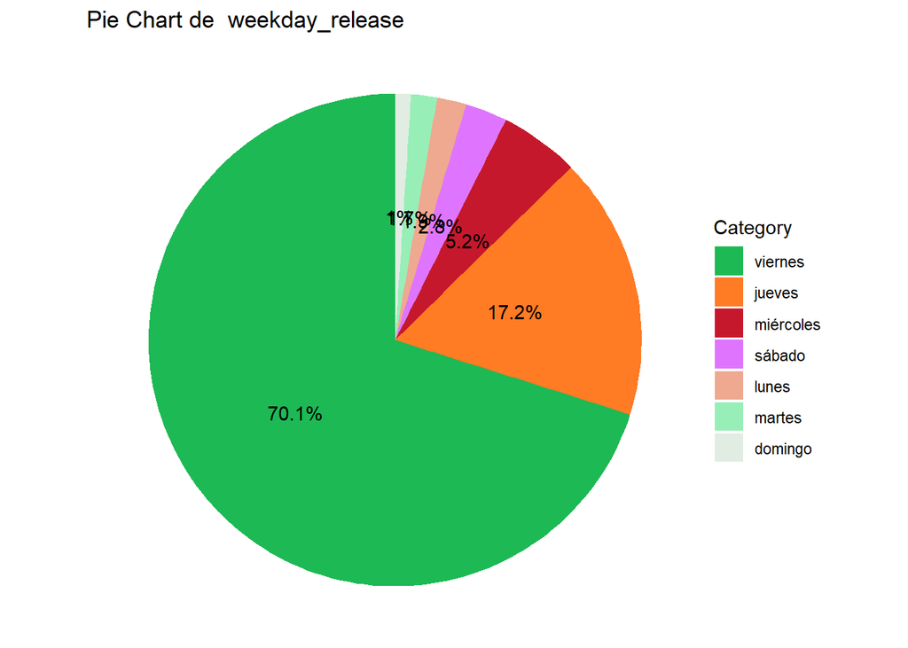

Nombre de modalitats: 7

Moda: viernes

Freqüència màxima: 5987

## year_week

[1] 2017 2017 2017 2017 2017 2017 Levels: 2017 2018 2019 2020 2021

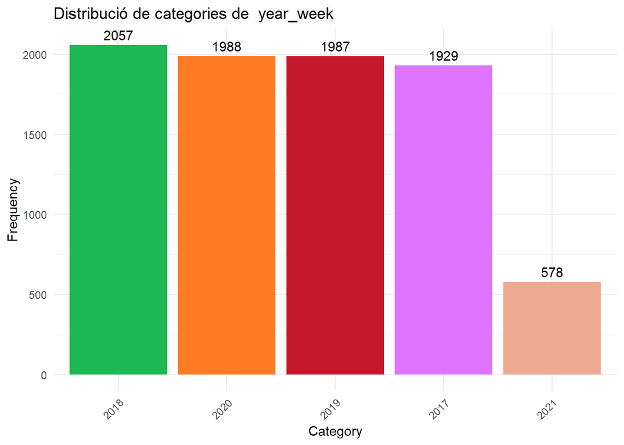

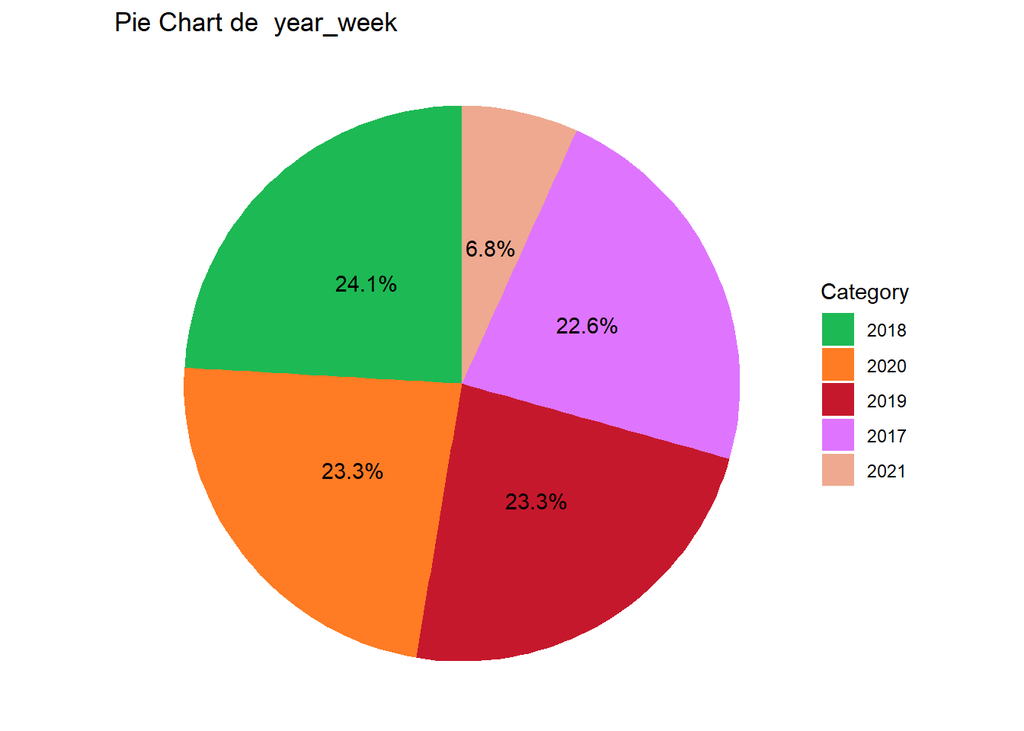

Nombre de modalitats: 5

Moda: 2018

Freqüència màxima: 2057

## month_week

[1] 1 1 1 1 1 1 Levels: 1 2 3 4 5 6 7 8 9 10 11 12

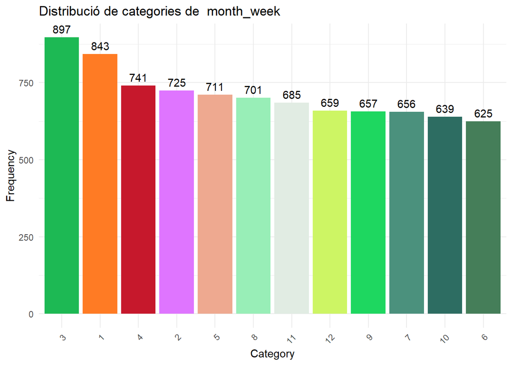

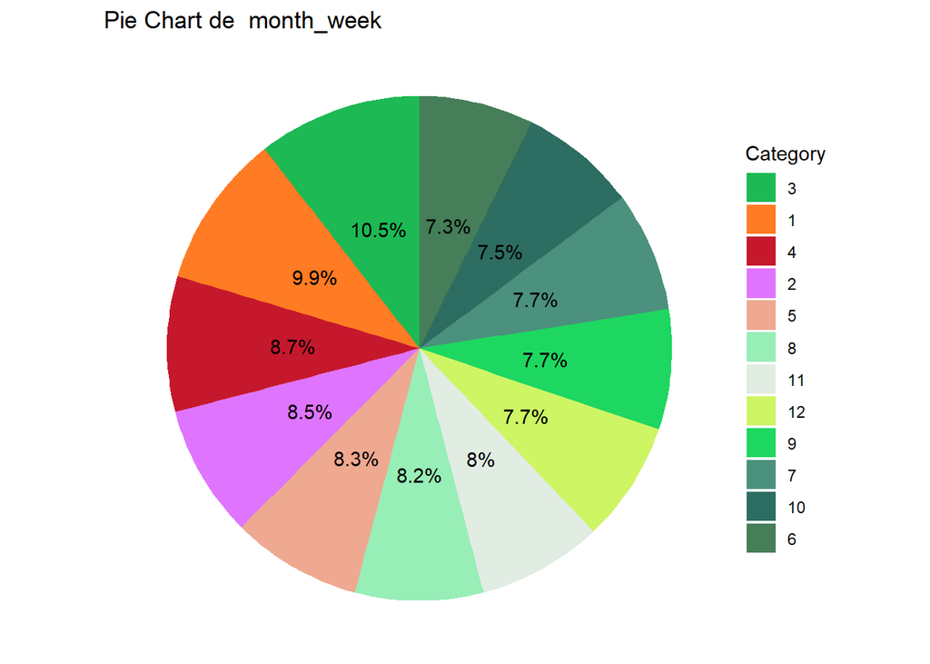

Nombre de modalitats: 12

Moda: 3

Freqüència màxima: 897

## week_index

[1] 1 1 1 1 1 1 221 Levels: 1 2 3 4 5 6 7 8 9 10 11 12 13 14 15 16 17 18 19 20 21 22 23 … 221

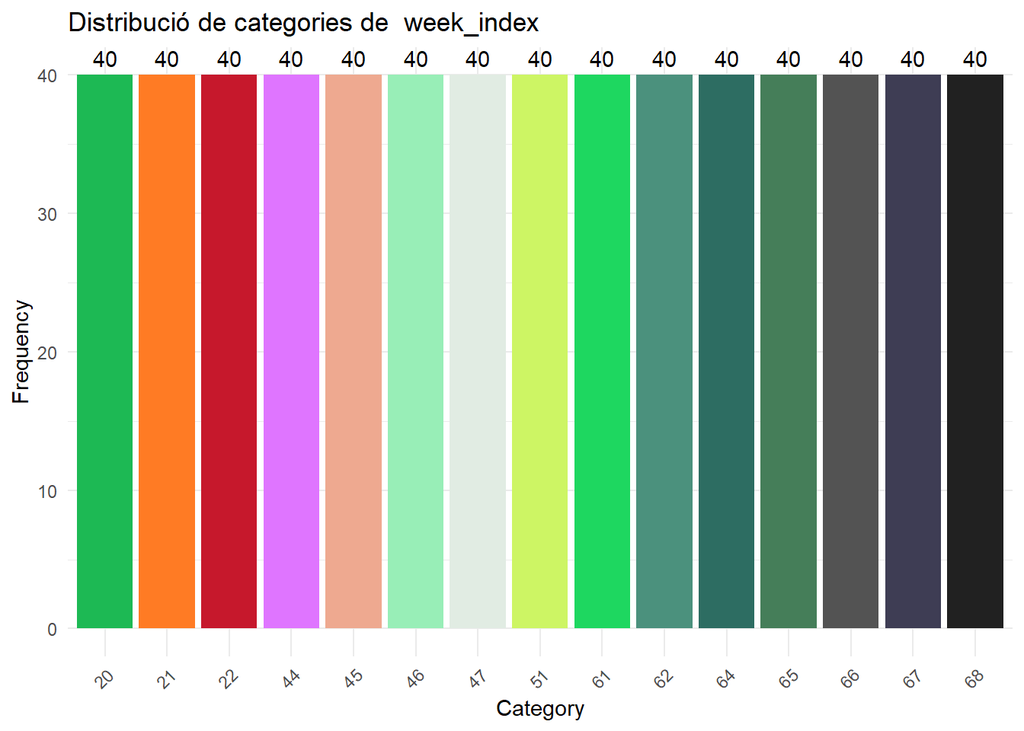

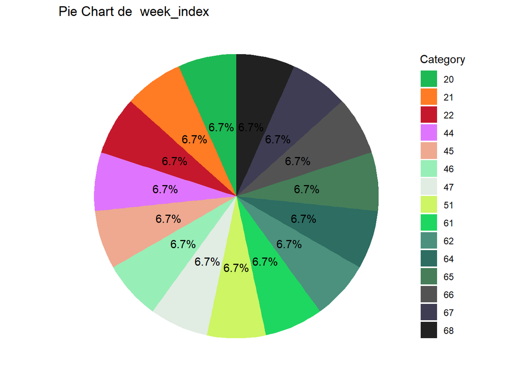

Nombre de modalitats: 221

Moda: 20

Freqüència màxima: 40

## rank_group

[1] 1-10 1-10 1-10 1-10 1-10 1-10 Levels: 1-10 11-20 21-30 31-40

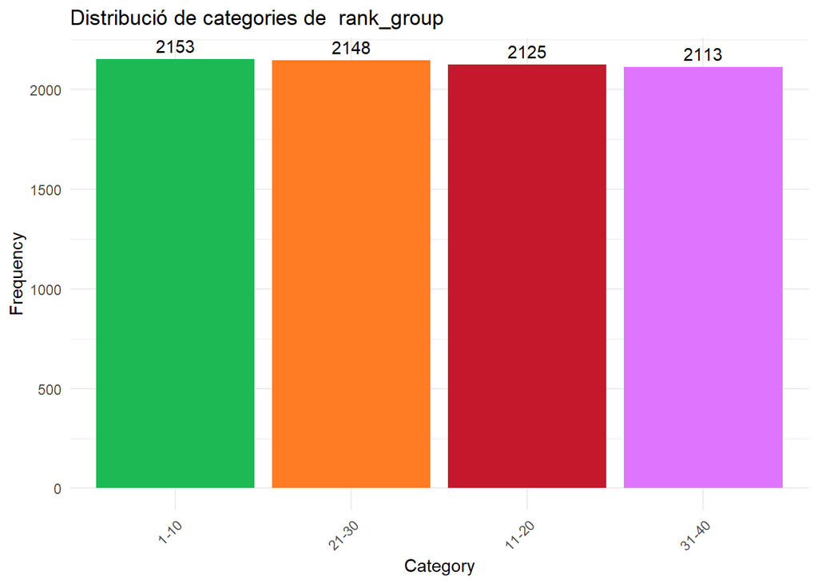

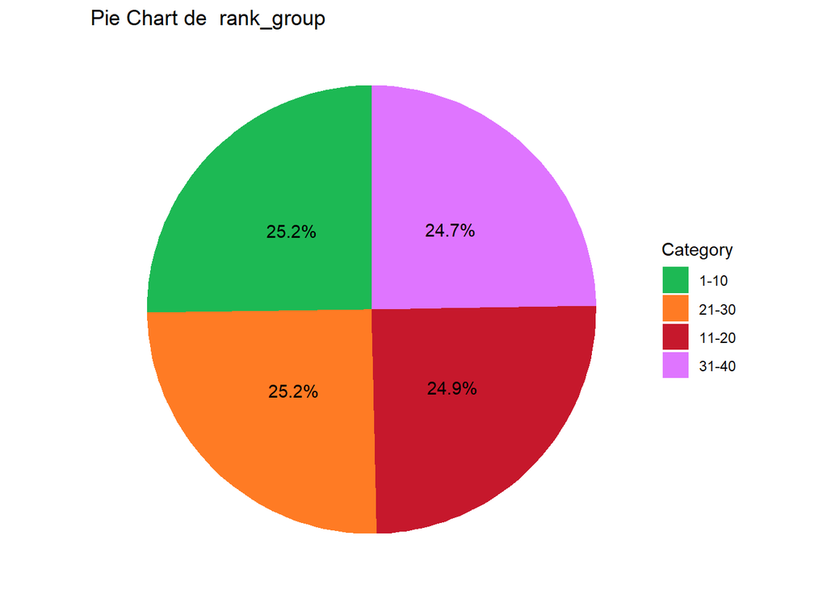

Nombre de modalitats: 4

Moda: 1-10

Freqüència màxima: 2153

## nationality

[1] Canada United States United Kingdom France England  
[6] United States 38 Levels: Argentina Australia Belgium Brazil Canada Chicago … Venezuela

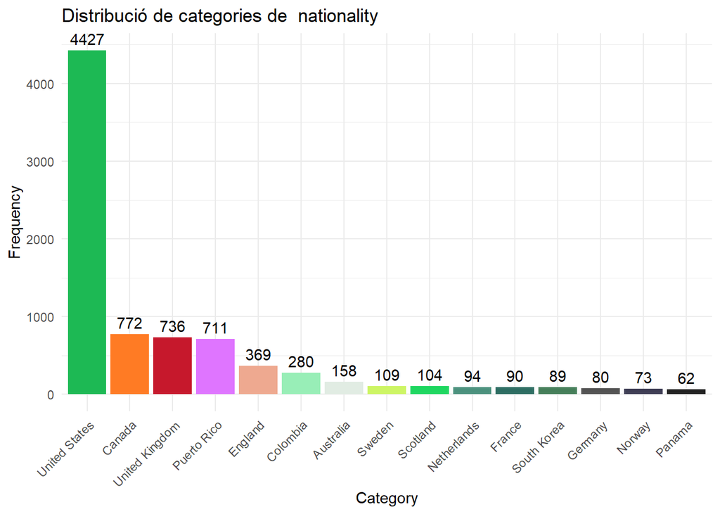

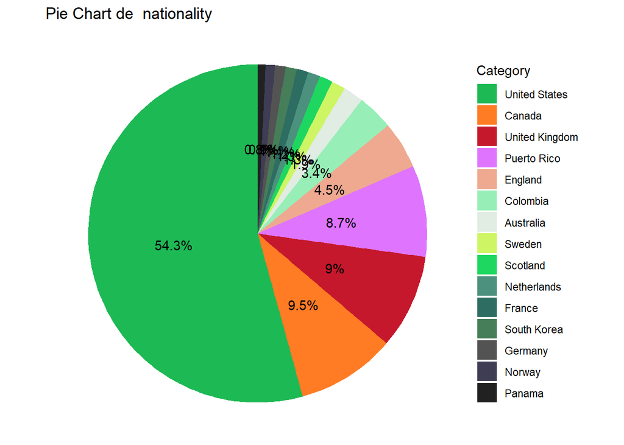

Nombre de modalitats: 38

Moda: United States

Freqüència màxima: 4427

## city

[1] Scarborough New York Cambridge Paris Bradford Los Angeles 202 Levels: Adelaide Agoura Hills Airdrie Albuquerque … Yemen

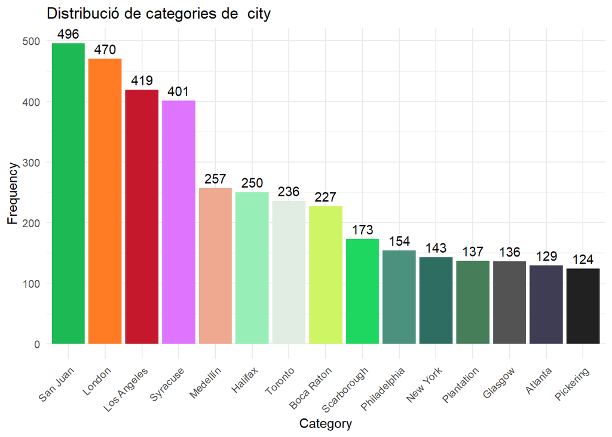

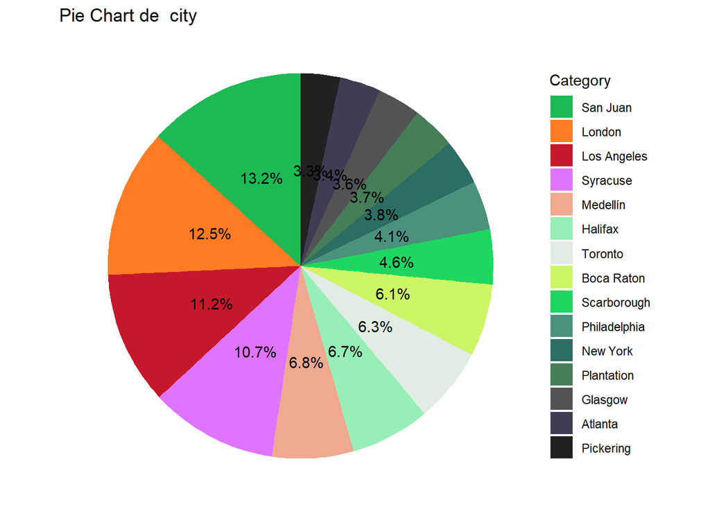

Nombre de modalitats: 202

Moda: San Juan

Freqüència màxima: 496

## gender

[1] male male mixed male male male Levels: female male mixed na non-binary

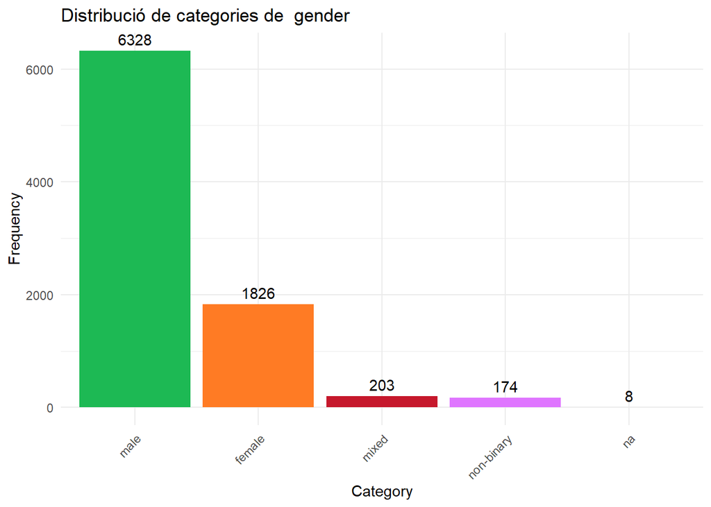

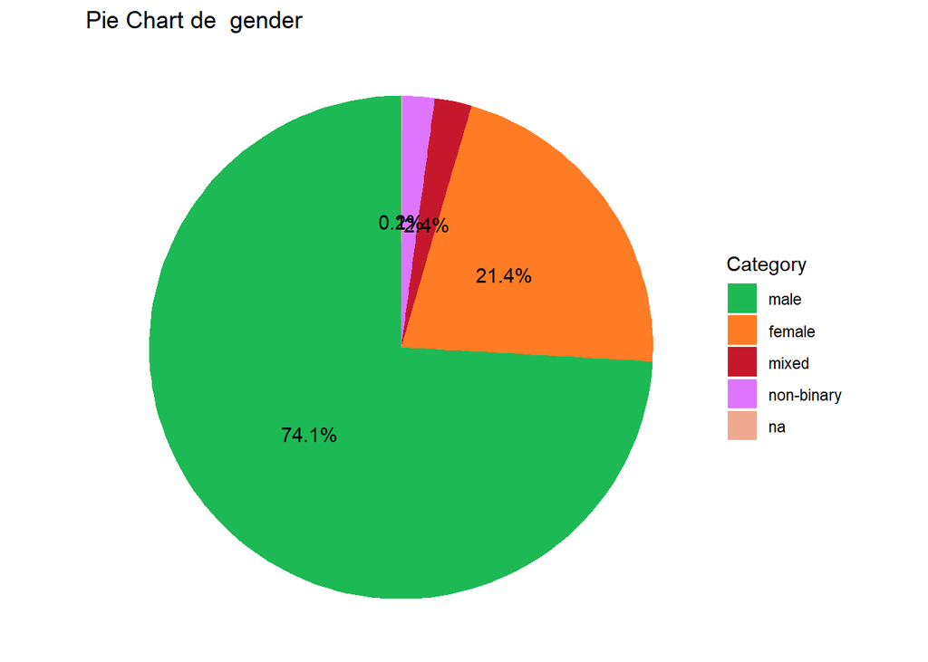

Nombre de modalitats: 5

Moda: male

Freqüència màxima: 6328

## is_group

[1] FALSE TRUE TRUE FALSE FALSE TRUE

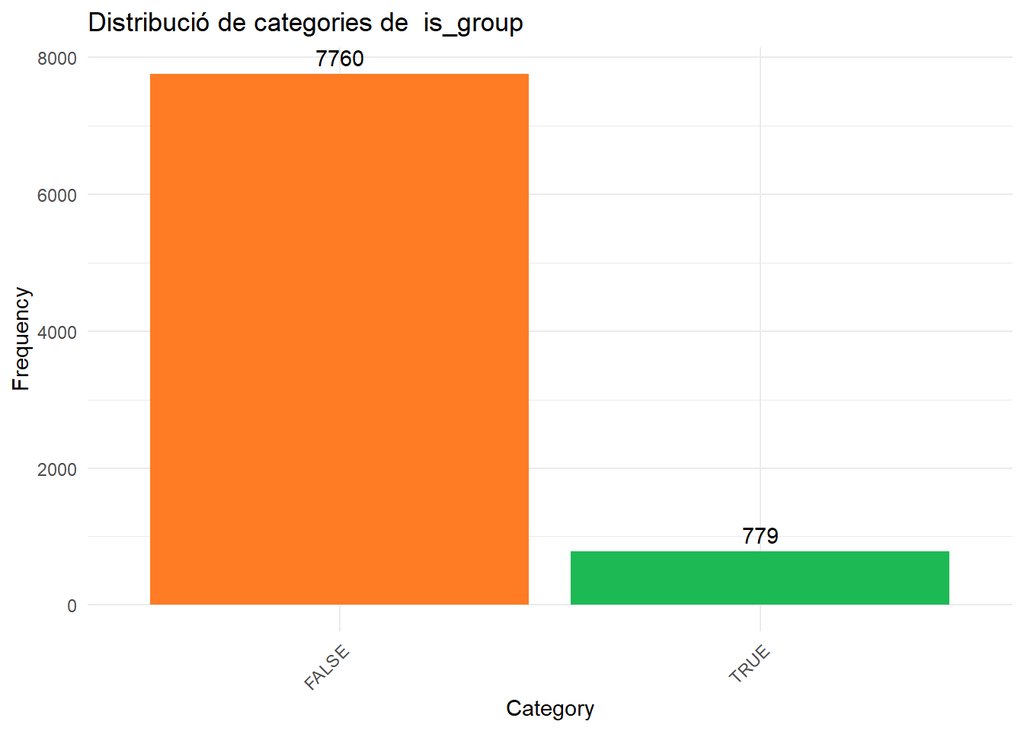

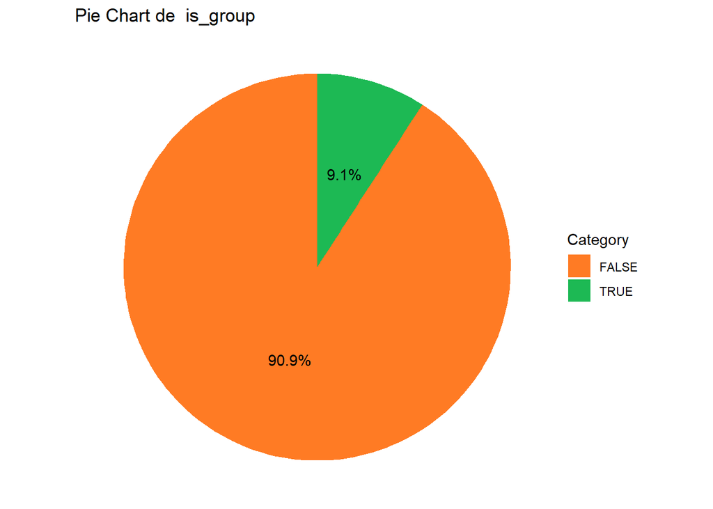

Nombre de modalitats: 2

Moda: FALSE

Freqüència màxima: 7760

## lyrics

```
                      data[, 46]
```

1 ‘m tryna put you in… 2 , I was doing just fine… 3 it love and devotion… 4 used to believewere … 5 sittin’ eyes wide ope… 6 , hey, oh hey, oh,…

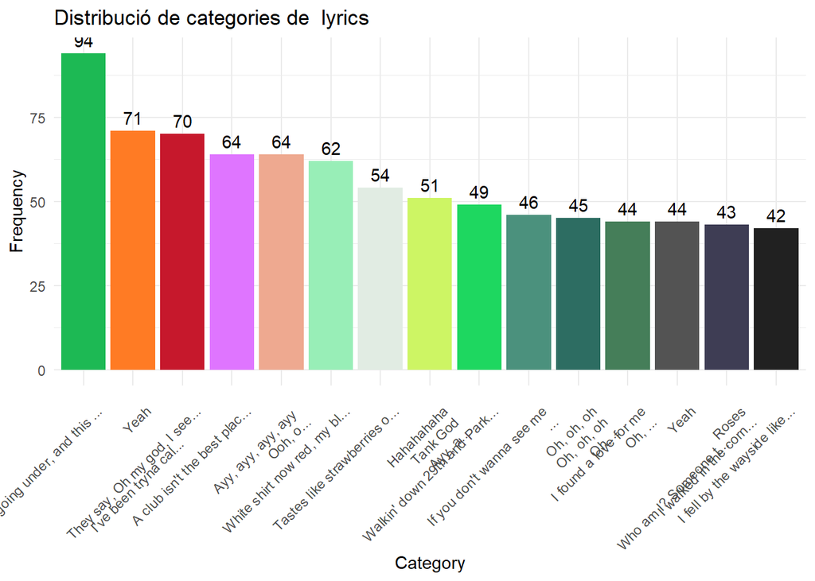

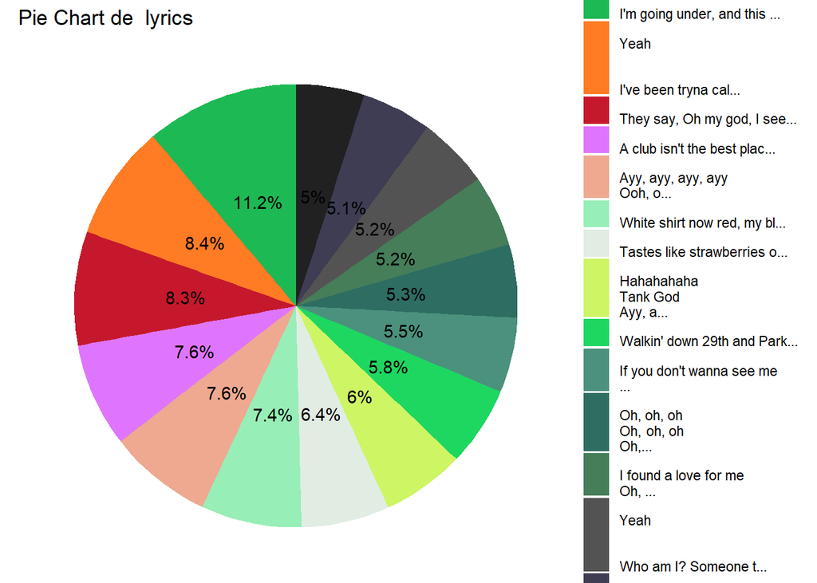

Nombre de modalitats: 969

Moda:  
I’m going under, and this …

Freqüència màxima: 94